# cm008: Notes and Exercises

2017-09-28

- 1. Statistical Modelling in R
  - 1.1 Linear Regression
  - 1.2 Generalized Linear Models (like Logistic Regression)
  - 1.3 Others...
- 2. More `dplyr`
- 3. More `ggplot`
  - 3.1 `theme` layers
  - 3.2 Modifying scales
- 4. Exercises.

```r
suppressPackageStartupMessages(library(tidyverse))
suppressPackageStartupMessages(library(gapminder))
```

We're ahead of schedule! As a result, I'll talk about a variety of things first, then we'll do some exercises.

## 1. Statistical Modelling in R

We'll look at typical data analyses using R.

**Note**:

- You aren't expected to apply this is in your assignments! It's new to the course because we're ahead of schedule.
- It's OK if you've never heard of these statistical analyses. The point is that many model fitting procedures in R are similar.

Many statistical analyses in R follow a similar syntax.

### 1.1 Linear Regression

#### Model Fitting

You can run a linear regression in R with the `lm` function. Syntax:

```
lm(y ~ x1 + x2 + ... + xp, data=your_data_frame)
```

The first argument is a "formula" object in R. It's typically used in modelling to separate Y and X values. (In fact, you've seen this already in `ggplot`'s `facet_wrap` and `facet_grid`)

Let's fit the regression curve that we see in this plot, using `lm`:

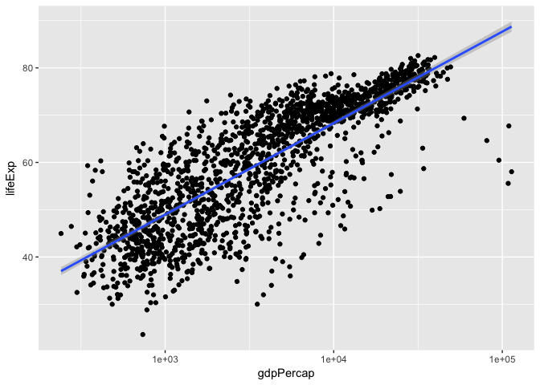

```r
ggplot(gapminder, aes(gdpPercap, lifeExp)) +
    geom_point() +
    geom_smooth(method="lm") +
    scale_x_log10()
```

Here's the code:

```r
fit1 <- lm(lifeExp ~ log(gdpPercap), data=gapminder)
```

What does this `fit1` object look like?

```r
fit1
```

```
##
## Call:
## lm(formula = lifeExp ~ log(gdpPercap), data = gapminder)
##
## Coefficients:
##    (Intercept)  log(gdpPercap)
##         -9.101           8.405
```

That's odd... what kind of R object is that??

```r
typeof(fit1)
```

```
## [1] "list"
```

It's a list, but R isn't presenting it that way. It just looks like a bunch of text, but it's not. Let's use the `lapply` function to uncover its true nature -- a list.

- NOTE:
  - `lapply` loops over each component of a vector or list (*first argument*), applies a function to it (that you specify in the *second argument*), and outputs the function output in a list.
  - Let's do this for an `lm` fit to `head(gapminder)`, so that the output doesn't take up a lot of space.

```r
fit1_small <- lm(lifeExp ~ log(gdpPercap), data=head(gapminder))
lapply(fit1_small, identity)
```

```
## $coefficients
##    (Intercept) log(gdpPercap)
##      187.61570      -23.08098
##
## $residuals
##          1          2          3          4          5          6
## -5.1280595 -2.4023520  0.1520397  1.7131151  0.9597015  4.7055553
##
## $effects
##    (Intercept) log(gdpPercap)
##     -81.517386       2.710390       2.070161       3.508404       2.004734
##
##       6.121766
##
## $rank
## [1] 2
##
## $fitted.values
##        1        2        3        4        5        6
## 33.92906 32.73435 31.84496 32.30688 35.12830 33.73244
##
## $assign
## [1] 0 1
##
## $qr
## $qr
##   (Intercept) log(gdpPercap)
## 1  -2.4494897    -16.3790824
## 2   0.4082483     -0.1174296
## 3   0.4082483      0.5987063
## 4   0.4082483      0.4282789
## 5   0.4082483     -0.6126834
## 6   0.4082483     -0.0976823
## attr(,"assign")
## [1] 0 1
##
## $qraux
## [1] 1.408248 1.270565
##
## $pivot
```

[output cut: 37 more lines]

```
## <environment: R_GlobalEnv>
## attr(,"predvars")
## list(lifeExp, log(gdpPercap))
## attr(,"dataClasses")
##        lifeExp log(gdpPercap)
##      "numeric"      "numeric"
##
## $model
##   lifeExp log(gdpPercap)
## 1  28.801       6.658583
## 2  30.332       6.710344
## 3  31.997       6.748878
## 4  34.020       6.728864
## 5  36.088       6.606625
## 6  38.438       6.667101
```

Why isn't R printing out the list, then? Because it's a special type of list -- it's of class `"lm"`, something that the makers of the `lm` function decided. Whenever R encounters this object, it also has a special way of printing it to screen.

This is the idea of the "object oriented" part of R -- something covered more in STAT 547 in the "R packages" section.

#### Making predictions from the model

The `predict` function works on `"lm"` objects to make predictions. If you don't specify new data, it will make predictions using the existing X values. Let's look at the first six:

```r
predict(fit1) %>% head
```

```
##        1        2        3        4        5        6
## 46.86506 47.30012 47.62400 47.45579 46.42835 46.93666
```

How about plotted against the original X values? (Which was log gdpPercap)

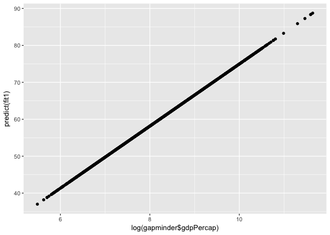

```r
qplot(log(gapminder$gdpPercap), predict(fit1))
```

For fun... let's put this overtop of the scatterplot:

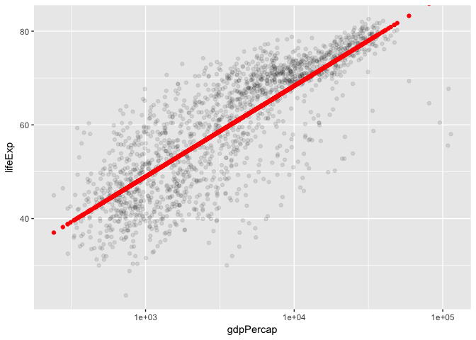

```r
ggplot(gapminder, aes(gdpPercap, lifeExp)) +
    geom_point(alpha=0.1) +
    geom_point(y=predict(fit1), colour="red") +
    scale_x_log10()
```

You can predict with new data, too, as long as the data frame you enter has the same column names as your X values.

```r
(my_newdata <- data.frame(gdpPercap=c(100, 547, 289)))
```

```
##   gdpPercap
## 1       100
## 2       547
## 3       289
```

```r
predict(fit1, newdata=my_newdata)
```

```
##        1        2        3
## 29.60596 43.88854 38.52591
```

```r
predict(fit1, newdata=filter(gapminder, country=="Canada"))
```

```
##        1        2        3        4        5        6        7        8
## 69.38986 70.18158 70.81182 72.30336 73.69461 74.97451 75.27641 76.54409
##        9       10       11       12
## 76.45408 77.24871 78.43120 79.15337
```

#### Extracting model characteristics

We can extract a bunch of things from the `lm` output.

- Regression coefficients? They're stored in the `$coefficients` part of the list. Or, use the `coeff` function.

```r
fit1$coefficients
```

```
##    (Intercept) log(gdpPercap)
##      -9.100889       8.405085
```

```r
coef(fit1)
```

```
##    (Intercept) log(gdpPercap)
##      -9.100889       8.405085
```

- Residuals? They're stored in the `$residuals` part of the list. Or, use the `resid` function. (Let's only display the first six... but plot all of them!)

```r
fit1$residuals %>% head
```

```
##          1          2          3          4          5          6
## -18.064063 -16.968123 -15.627000 -13.435788 -10.340352  -8.498661
```

```r
resid(fit1) %>% head
```

```
##          1          2          3          4          5          6
## -18.064063 -16.968123 -15.627000 -13.435788 -10.340352  -8.498661
```

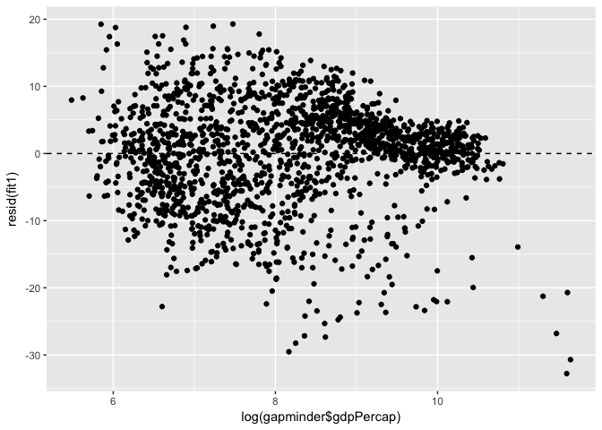

```r
qplot(log(gapminder$gdpPercap), resid(fit1)) +
    geom_hline(yintercept=0,
               linetype="dashed")
```

`lm` is kind of annoying in that not everything you might want is there. You can access more things using the `summary` function. What's printed to screen after `summary`, though, *is* quite nice!

```r
(summ_fit1 <- summary(fit1))
```

```
##
## Call:
## lm(formula = lifeExp ~ log(gdpPercap), data = gapminder)
##
## Residuals:
##     Min      1Q  Median      3Q     Max
## -32.778  -4.204   1.212   4.658  19.285
##
## Coefficients:
##                Estimate Std. Error t value Pr(>|t|)
## (Intercept)     -9.1009     1.2277  -7.413 1.93e-13 ***
## log(gdpPercap)   8.4051     0.1488  56.500  < 2e-16 ***
## ---
## Signif. codes:  0 '***' 0.001 '**' 0.01 '*' 0.05 '.' 0.1 ' ' 1
##
## Residual standard error: 7.62 on 1702 degrees of freedom
## Multiple R-squared:  0.6522, Adjusted R-squared:  0.652
## F-statistic:  3192 on 1 and 1702 DF,  p-value: < 2.2e-16
```

You can see all sorts of things, like p-values, *R*<sup>2</sup> (and adjusted *R*<sup>2</sup> values), and standard errors.

As before, this looks nice and all... but what the heck is this new object? Again, it's a list. Let's see its components (again, with the smaller fit, so that we don't take over all the space on the screen).

```r
summ_fit1_small <- summary(fit1_small)
typeof(summ_fit1_small)
```

```
## [1] "list"
```

```r
lapply(summ_fit1_small, identity)  # Pry it open!!
```

```
## $call
## lm(formula = lifeExp ~ log(gdpPercap), data = head(gapminder))
##
## $terms
## lifeExp ~ log(gdpPercap)
## attr(,"variables")
## list(lifeExp, log(gdpPercap))
## attr(,"factors")
##                log(gdpPercap)
## lifeExp                     0
## log(gdpPercap)              1
## attr(,"term.labels")
## [1] "log(gdpPercap)"
## attr(,"order")
## [1] 1
## attr(,"intercept")
## [1] 1
## attr(,"response")
## [1] 1
## attr(,".Environment")
## <environment: R_GlobalEnv>
## attr(,"predvars")
## list(lifeExp, log(gdpPercap))
## attr(,"dataClasses")
##        lifeExp log(gdpPercap)
##      "numeric"      "numeric"
##
## $residuals
##          1          2          3          4          5          6
## -5.1280595 -2.4023520  0.1520397  1.7131151  0.9597015  4.7055553
##
## $coefficients
##                 Estimate Std. Error    t value  Pr(>|t|)
## (Intercept)    187.61570  217.00328  0.8645754 0.4360391
## log(gdpPercap) -23.08098   32.45198 -0.7112350 0.5162158
##
## $aliased
##    (Intercept) log(gdpPercap)
##          FALSE          FALSE
##
## $sigma
## [1] 3.810822
##
## $df
## [1] 2 4 2
##
## $r.squared
## [1] 0.1122662
##
## $adj.r.squared
## [1] -0.1096672
##
## $fstatistic
##     value     numdf     dendf
## 0.5058553 1.0000000 4.0000000
##
## $cov.unscaled
##                (Intercept) log(gdpPercap)
## (Intercept)      3242.6148     -484.90771
## log(gdpPercap)   -484.9077       72.51789
```

There we have it. Now, what would you like to extract?:

- R-squared? R-squared adjusted? Okay:

```r
summ_fit1$r.squared
```

```
## [1] 0.6522466
```

```r
summ_fit1$adj.r.squared
```

```
## [1] 0.6520423
```

- Estimated standard devaition of the random error term? Okay:

```r
summ_fit1$sigma
```

```
## [1] 7.619535
```

Where can we find the documentation for the components of *this* list, though, if it's not in the documentation for `lm`? Look at the documentation of `summary.lm`.

But wait! Why not just look at the documentation for `summary`? It's because `summary` is a generic function, and depends on the *class* of object it's being applied to. If it's of class `"lm"`, then `summary.lm` is what's actually secretly run. Running `summary` on an object of class `"glm"`? R will secretly run `summary.glm` instead.

PS: The `broom` package makes a lot of this easier and less cryptic. We won't go over it here. Check out [its vignette](https://cran.r-project.org/web/packages/broom/vignettes/broom.html).

### 1.2 Generalized Linear Models (like Logistic Regression)

We won't go over this in as much detail, because it's quite similar to `lm`. But if you want to run a Generalized Linear Model (GLM) -- such as logistic/binomial regression, or Poission regression -- just use the `glm` function.

Probably the biggest noteworthy difference is the `family` argument, specifying what type of regression you want to do. Syntax:

```
## Poisson regression:
glm(y ~ x1 + x2 + ... + xp, family=poisson, data=your_data_frame)
## Logistic (aka Binomial) regression:
glm(y ~ x1 + x2 + ... + xp, family=binomial, data=your_data_frame)
```

Its output looks similar to `lm`. It's also a list disguised as text. It also shows more when you use the `summary` function. It also works with the `predict` function. It also becomes tidier when used in conjunction with the `broom` package.

### 1.3 Others...

Here are some other packages/functions you might find useful to fit models:

- (Generalized) Mixed Effects Models
  - Two R packages are available: `lme4` and `nlme`.
    - Check out [this](http://stats.stackexchange.com/questions/5344/how-to-choose-nlme-or-lme4-r-library-for-mixed-effects-models) discussion on Cross Validated for a comparison of the two packages.
  - I've found the function `glmer` in the `lme4` package to be fruitful.
- Kernel smoothing (i.e. fitting a "smoother"): check out the `loess` function.
- Generalized Additive Models: The `gam` function in *either* the `gam` package or `mgcv` package.
- Robust linear regression: The `rlm` function in the `MASS` package is your friend.
- Regularized regression (GLM) (lasso, elastic net, or ridge regression): Use the `glmnet` function in the `glmnet` package.
  - PS: I *highly* recommend this if you have more predictors/covariates/features than you know what to do with... this will weed out the unnecessary ones, *and* produce a model with good prediction accuracy at the same time.

## 2. More `dplyr`

There's one more important thing with `dplyr` that you ought to know: applying `mutate` to a grouped tibble.

Remember applying `summarize` to a grouped tibble?

```r
gapminder %>%
    group_by(continent) %>%
    summarize(mean_gdpPercap = mean(gdpPercap),
              n_countries    = length(gdpPercap))
```

```
## # A tibble: 5 x 3
##   continent mean_gdpPercap n_countries
##      <fctr>          <dbl>       <int>
## 1    Africa       2193.755         624
## 2  Americas       7136.110         300
## 3      Asia       7902.150         396
## 4    Europe      14469.476         360
## 5   Oceania      18621.609          24
```

Well, we can also apply `mutate` to each group, too. For example, let's calculate the growth in population since the first year on record *for each country*:

```r
gapminder %>%
    group_by(country) %>%
    mutate(pop_growth = pop - pop[1])
```

```
## # A tibble: 1,704 x 7
## # Groups:   country [142]
##        country continent  year lifeExp      pop gdpPercap pop_growth
##         <fctr>    <fctr> <int>   <dbl>    <int>     <dbl>      <int>
##  1 Afghanistan      Asia  1952  28.801  8425333  779.4453          0
##  2 Afghanistan      Asia  1957  30.332  9240934  820.8530     815601
##  3 Afghanistan      Asia  1962  31.997 10267083  853.1007    1841750
##  4 Afghanistan      Asia  1967  34.020 11537966  836.1971    3112633
##  5 Afghanistan      Asia  1972  36.088 13079460  739.9811    4654127
##  6 Afghanistan      Asia  1977  38.438 14880372  786.1134    6455039
##  7 Afghanistan      Asia  1982  39.854 12881816  978.0114    4456483
##  8 Afghanistan      Asia  1987  40.822 13867957  852.3959    5442624
##  9 Afghanistan      Asia  1992  41.674 16317921  649.3414    7892588
## 10 Afghanistan      Asia  1997  41.763 22227415  635.3414   13802082
## # ... with 1,694 more rows
```

Notice that `dplyr` has retained the original grouping -- it hasn't pealed back one level of grouping. That's because there's still more than one row for each group!

How about growth compared to `1972`?

```r
gapminder %>%
    group_by(country) %>%
    mutate(pop_growth = pop - pop[year==1972])
```

```
## # A tibble: 1,704 x 7
## # Groups:   country [142]
##        country continent  year lifeExp      pop gdpPercap pop_growth
##         <fctr>    <fctr> <int>   <dbl>    <int>     <dbl>      <int>
##  1 Afghanistan      Asia  1952  28.801  8425333  779.4453   -4654127
##  2 Afghanistan      Asia  1957  30.332  9240934  820.8530   -3838526
##  3 Afghanistan      Asia  1962  31.997 10267083  853.1007   -2812377
##  4 Afghanistan      Asia  1967  34.020 11537966  836.1971   -1541494
##  5 Afghanistan      Asia  1972  36.088 13079460  739.9811          0
##  6 Afghanistan      Asia  1977  38.438 14880372  786.1134    1800912
##  7 Afghanistan      Asia  1982  39.854 12881816  978.0114    -197644
##  8 Afghanistan      Asia  1987  40.822 13867957  852.3959     788497
##  9 Afghanistan      Asia  1992  41.674 16317921  649.3414    3238461
## 10 Afghanistan      Asia  1997  41.763 22227415  635.3414    9147955
## # ... with 1,694 more rows
```

In general, this type of "grouped mutation" is useful for *window functions*. What's that? Well, let's see other types of functions in R:

- **Vectorized Functions**: These take a vector, and operate on each component independently to return a vector of the same length. In other words, they work element-wise.
  - Examples are `cos`, `sin`, `log`, `exp`, `round`.
  - We don't need to `group_by` in order to `mutate` with these.
- **Aggregate Functions**: These take a vector, and return a vector of length 1 -- as if "aggregating" the values in the vector into a single value.
  - Examples are `mean`, `sd`, `length`, `typeof`.
  - We use these in dplyr's `summarise` function.
- **Window Functions**: these take a vector, and return a vector of the same length *that depends on other values in the vector*.
  - Examples are `lag`, `rank`, `cumsum`.
  - See the [window-functions](https://cran.r-project.org/web/packages/dplyr/vignettes/window-functions.html) vignette for the `dplyr` package.

## 3. More `ggplot`

(Have you seen the [ggplot2 cheatsheet](https://www.rstudio.com/wp-content/uploads/2015/03/ggplot2-cheatsheet.pdf)? It contains **a lot** of useful information on two pages!)

### 3.1 `theme` layers

You can change the look of a plot by adding a `theme` layer to your ggplot layers. This function does **not** actually change the "nature" of the plot itself -- only the look! i.e., the so-called "non-data" type displays.

Examples: - font - justification of titles - rotation of labels - background colour - line thickness - etc...

There are ["complete themes"](http://ggplot2.tidyverse.org/reference/ggtheme.html) that come with `ggplot2`, my favourite being `theme_bw` (I've grown tired of the default gray background, so `theme_bw` is refreshing).

Let's see an example:

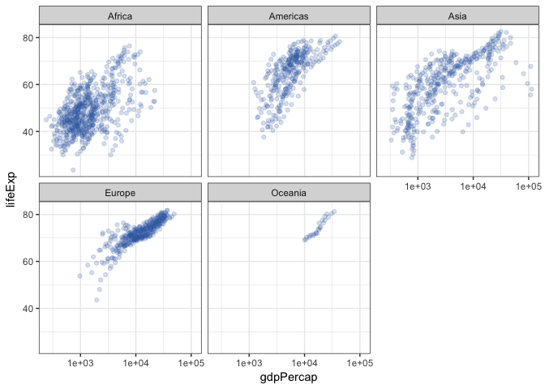

```r
p1 <- ggplot(gapminder, aes(gdpPercap, lifeExp)) +
    facet_wrap(~ continent) +
    geom_point(colour="#386CB0", alpha=0.2) +
    scale_x_log10()
p1 + theme_bw()
```

The general `theme` function gives you vast functionality... just check its documentation to see what things you can change. The arguments of `theme` follow a naming convention: `general.to.specific`

For example, - `axis.title` will allow you to change the font of the axis titles. - `axis.title.x` does the same, but focusses on the `x` axis.

**Note**: You *can't* change the actual words this way! That's changing the nature of the plot, and not the *look* of the plot.

Once we've chosen an argument name, we need to specify its value. This is almost always the output of one of the following functions:

- `element_blank` (basically means replace with "nothing")
- `element_rect`: allows us to specify features of a *rectangle*.
- `element_line`: allows us to specify features of a *line*.
- `element_text`: allows us to specify font.

Check out their documentation to see exactly how each feature is modified.

- **Example**: To `p1` above, do all of the following....
  - change the background strip colour to orange,
  - change the axis titles' font sizes to 14, and
  - change the panel titles' font sizes to 14 and bolded.

```r
p1 +
    theme(strip.background = element_rect(fill="orange"),
          axis.title = element_text(size=14),
          strip.text = element_text(size=14, face="bold"))
```

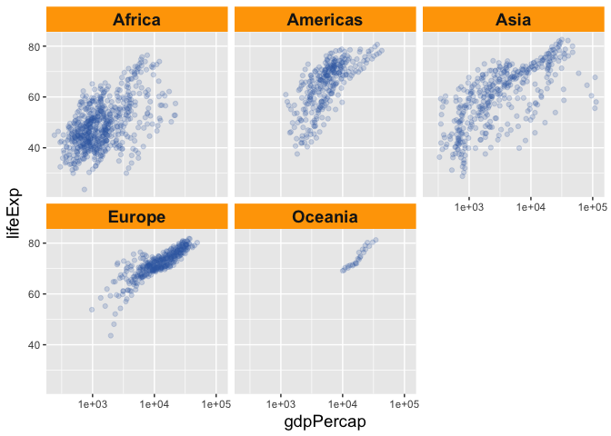

**Another example**: do the same, but in conjunction with the `theme_bw` (notice the order)

```r
## Correct:
p1 +
    theme_bw() +
    theme(strip.background = element_rect(fill="orange"),
          axis.title = element_text(size=14),
          strip.text = element_text(size=14, face="bold"))
```

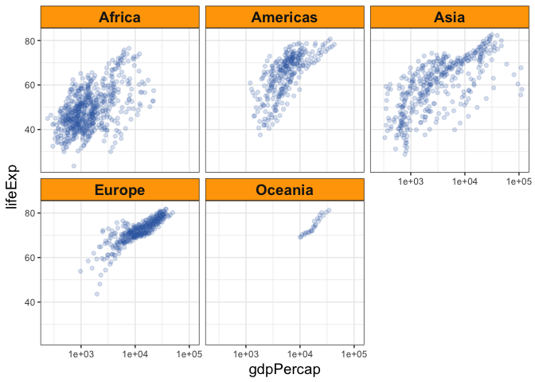

```r
## Incorrect:
p1 +
    theme(strip.background = element_rect(fill="orange"),
          axis.title = element_text(size=14),
          strip.text = element_text(size=14, face="bold")) +
    theme_bw()  # Overrides the previous `theme` call!
```

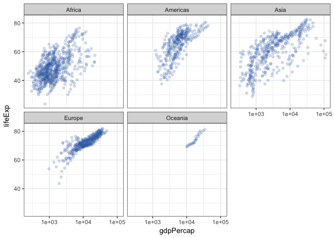

### 3.2 Modifying scales

Recall that we use some *scale* to represent the *range of values that a variable takes* in our data. `ggplot` chooses defaults for this scale, but we can change those.

Check out [this tutorial by Hadley Wickham](https://github.com/hadley/ggplot2-book/blob/master/scales.rmd) for scales.

We can modify scales using a suite of functions that have the following naming convention: `scale_a_b`, where:

- `a` is the scale you want to change. Is it `colour`? `size`? `x` position?
- `b` typically speaks to the nature of the variable. `continuous` is your variable is continuous; `discrete` if discrete. But, could be other things in certain cases, like `log10`, or `date` if your variable consists of dates. `manual` is an option too.

**Examples**: `scale_x_continuous`, `scale_colour_discrete`, `scale_y_sqrt`.

As usual in ggplot, these functions are added as a layer.

#### Useful arguments

There are many useful arguments here. Some are more self-explanatory than others.

- `name`. The first argument. Indicate the name of the scale/legend here.
  - You can also use the `labs` function for X and Y axes, and even plot title.

```r
p1 + scale_y_continuous("Life Expectancy")
```

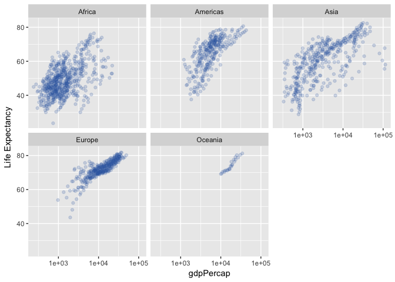

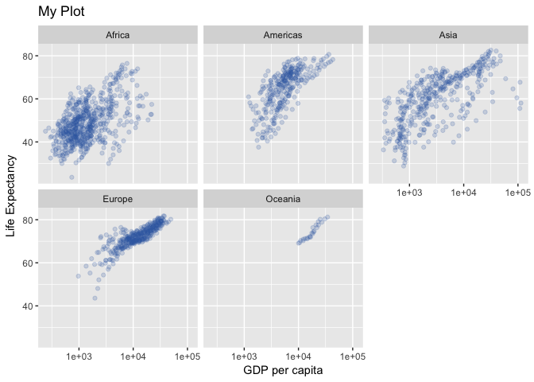

```r
p1 + labs(x="GDP per capita",
          y="Life Expectancy",
          title="My Plot")
```

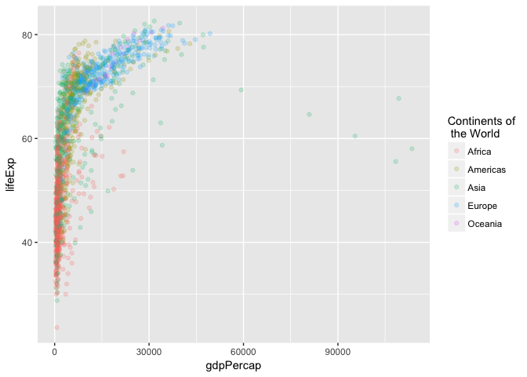

```r
ggplot(gapminder, aes(gdpPercap, lifeExp)) +
    geom_point(aes(colour=continent),
               alpha=0.2) +
    scale_colour_discrete("Continents of\n the World")
```

- `breaks` (Typically of a continuous scale). Here, you get to specify *where* along the scale you'd like to display a value.
  - Numbers are on the scale of the data (such as population), not the geometric scale (such as a hex colour code, or number of pixels over in a plot).

```r
## Log lines:
p1 + scale_x_log10(breaks=c((1:10)*1000,
                            (1:10)*10000))
```

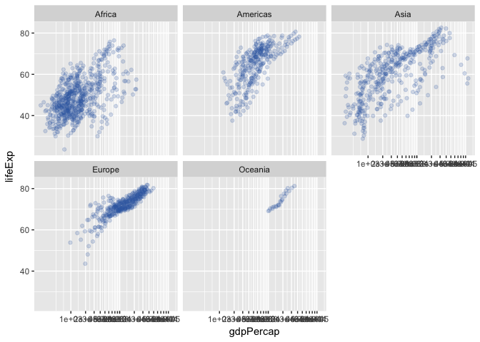

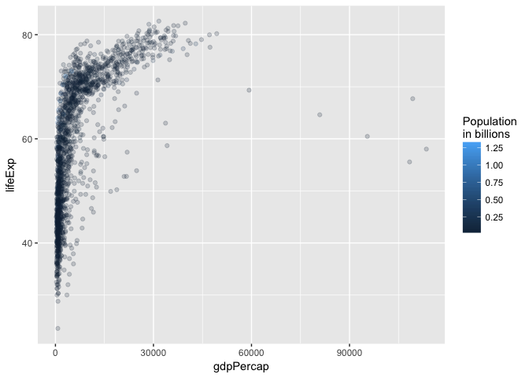

```r
p2 <- ggplot(gapminder, aes(gdpPercap, lifeExp)) +
    geom_point(aes(colour=pop/10^9),
               alpha=0.2)
## Default breaks
p2 + scale_colour_continuous("Population\nin billions")
```

```r
## New breaks
p2 + scale_colour_continuous("Population\nin billions",
                             breaks=seq(0,2,by=0.2))
```

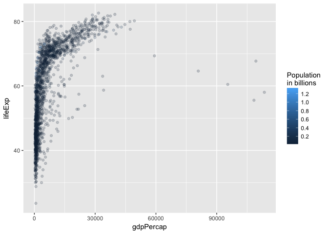

- `labels`. Text to replace the data value labels. Most useful for discrete data.

```r
## Not a good idea:
p2 + scale_colour_continuous("My odd\npopulation\nscale",
                             breaks=c(0.2, 0.7, 1.2),
                             labels=c("small", "bigger", "big"))
```

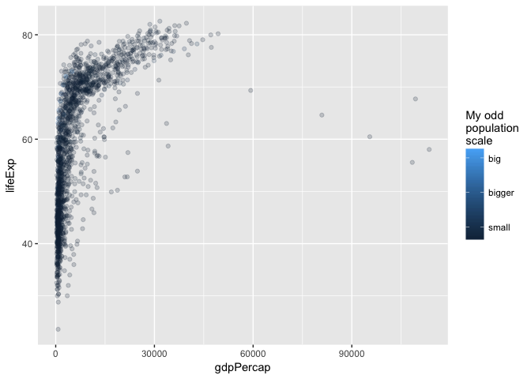

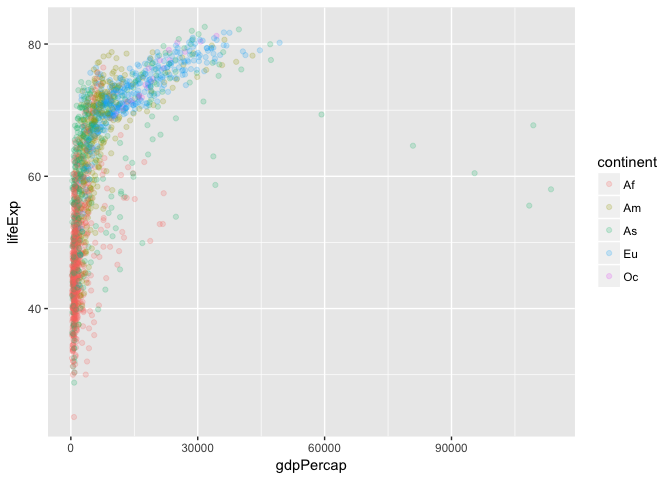

```r
## Discrete scale:
ggplot(gapminder, aes(gdpPercap, lifeExp)) +
    geom_point(aes(colour=continent),
               alpha=0.2) +
    scale_colour_discrete(labels=c("Af", "Am", "As", "Eu", "Oc"))
```

- `limits`. Lower and upper bounds of the data that you'd like displayed. Leave one as `NA` if you want to use the default.

```r
p1 + scale_y_continuous(limits=c(60,NA))
```

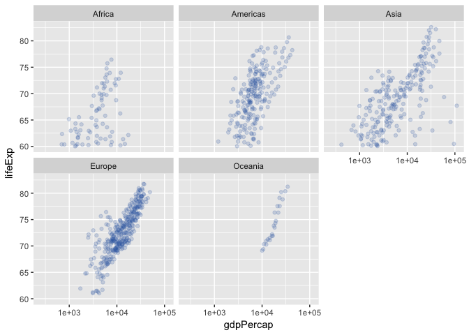

- `position`. Position of the scale. Also controllable using `theme` for the legend.

```r
p1 + scale_y_continuous(position="right")
```

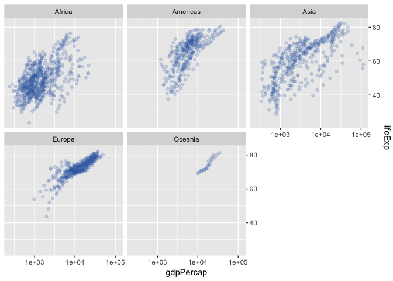

```r
p2 + theme(legend.position = "bottom")
```

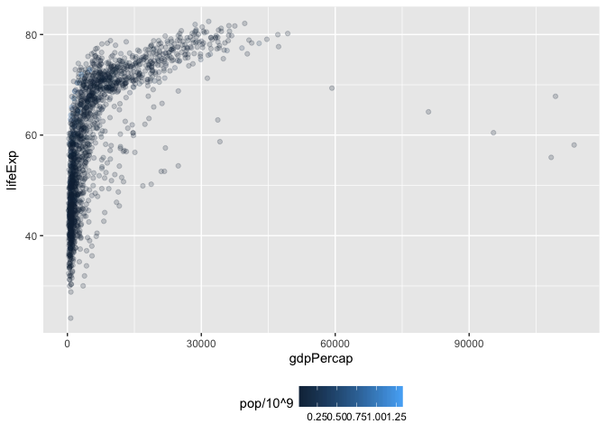

## 4. Exercises.

Practice these concepts in the following exercises.

**Exercise 1**: Suppose we want to calculate some quantity for each country in the `gapminder` data set. For each of the following quantities, indicate whether the function is *vectorized*, *aggregate*, or *window*, and use `dplyr` functions to calculate the specified variable.

- The change in population from 1962 to 1972.

```r
## It's an Aggregate function.
gapminder %>%
    filter(year %in% c(1962, 1972)) %>%
    arrange(year) %>%
    group_by(country) %>%
    summarize(pop_chg=diff(pop))
```

```
## # A tibble: 142 x 2
##        country  pop_chg
##         <fctr>    <int>
##  1 Afghanistan  2812377
##  2     Albania   535417
##  3     Algeria  3759839
##  4      Angola  1068843
##  5   Argentina  3496016
##  6   Australia  2382032
##  7     Austria   414337
##  8     Bahrain    58937
##  9  Bangladesh 13920006
## 10     Belgium   490700
## # ... with 132 more rows
```

```r
gapminder %>%
    group_by(country) %>%
    summarise(pop_chg=pop[year==1972]-pop[year==1962])
```

```
## # A tibble: 142 x 2
##        country  pop_chg
##         <fctr>    <int>
##  1 Afghanistan  2812377
##  2     Albania   535417
##  3     Algeria  3759839
##  4      Angola  1068843
##  5   Argentina  3496016
##  6   Australia  2382032
##  7     Austria   414337
##  8     Bahrain    58937
##  9  Bangladesh 13920006
## 10     Belgium   490700
## # ... with 132 more rows
```

- The population, in billions.

```r
## It's a vectorized function.
gapminder %>%
    mutate(pop_in_bill = pop/10^9)
```

```
## # A tibble: 1,704 x 7
##        country continent  year lifeExp      pop gdpPercap pop_in_bill
##         <fctr>    <fctr> <int>   <dbl>    <int>     <dbl>       <dbl>
##  1 Afghanistan      Asia  1952  28.801  8425333  779.4453 0.008425333
##  2 Afghanistan      Asia  1957  30.332  9240934  820.8530 0.009240934
##  3 Afghanistan      Asia  1962  31.997 10267083  853.1007 0.010267083
##  4 Afghanistan      Asia  1967  34.020 11537966  836.1971 0.011537966
##  5 Afghanistan      Asia  1972  36.088 13079460  739.9811 0.013079460
##  6 Afghanistan      Asia  1977  38.438 14880372  786.1134 0.014880372
##  7 Afghanistan      Asia  1982  39.854 12881816  978.0114 0.012881816
##  8 Afghanistan      Asia  1987  40.822 13867957  852.3959 0.013867957
##  9 Afghanistan      Asia  1992  41.674 16317921  649.3414 0.016317921
## 10 Afghanistan      Asia  1997  41.763 22227415  635.3414 0.022227415
## # ... with 1,694 more rows
```

- The lagged gdpPercap
  - i.e., the value that appears for 1962 would be the gdpPercap in 1957 (the previous entry).
  - Hint: use the `lag` function, then filter out the `NA`'s created with the `is.na` function.

```r
## It's a window function.
gapminder %>%
    group_by(country) %>%
    arrange(year) %>%
    mutate(lag_gdpPercap=lag(gdpPercap)) %>%
    filter(!is.na(lag_gdpPercap))
```

```
## # A tibble: 1,562 x 7
## # Groups:   country [142]
##        country continent  year lifeExp      pop  gdpPercap lag_gdpPercap
##         <fctr>    <fctr> <int>   <dbl>    <int>      <dbl>         <dbl>
##  1 Afghanistan      Asia  1957  30.332  9240934   820.8530      779.4453
##  2     Albania    Europe  1957  59.280  1476505  1942.2842     1601.0561
##  3     Algeria    Africa  1957  45.685 10270856  3013.9760     2449.0082
##  4      Angola    Africa  1957  31.999  4561361  3827.9405     3520.6103
##  5   Argentina  Americas  1957  64.399 19610538  6856.8562     5911.3151
##  6   Australia   Oceania  1957  70.330  9712569 10949.6496    10039.5956
##  7     Austria    Europe  1957  67.480  6965860  8842.5980     6137.0765
##  8     Bahrain      Asia  1957  53.832   138655 11635.7995     9867.0848
##  9  Bangladesh      Asia  1957  39.348 51365468   661.6375      684.2442
## 10     Belgium    Europe  1957  69.240  8989111  9714.9606     8343.1051
## # ... with 1,552 more rows
```

**Exercise 2**: For the `gapminder` dataset, make a spaghetti plot showing the population trend (in millions) over time for each country, facetted by continent. Make as many of the following modifications as you can:

- Colour each line by the log maximum gdpPercap experienced by the country.
- Rotate the x-axis labels to be vertical.
- Remove the x-axis title.
- Give the legend an appropriate title.
- Put the y-axis on a log-scale.
- Rename the y-axis title.
- Add more numbers along the y-axis.
- Give the plot a title, and center the title.
- Only label the x axis with years 1950, 1975, and 2000.
- Move the colour scale to the bottom.
- Rename the colour legend

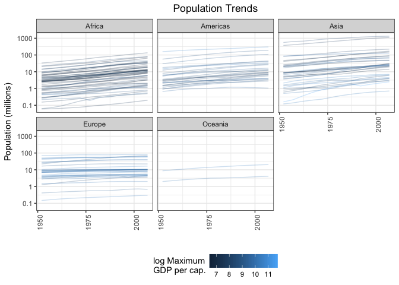

```r
gapminder %>%
    group_by(country) %>%
    mutate(max_gdpPercap=max(gdpPercap)) %>%
    ggplot(aes(year, pop/10^6)) +
    facet_wrap(~ continent) +
    geom_line(aes(group=country,
                  colour=log(max_gdpPercap)),
              alpha=0.25) +
    theme_bw() + # I added this because I like this theme.
    labs(title="Population Trends") +
    scale_y_log10("Population (millions)",
                  breaks=c(0.1, 1, 10, 100, 1000),
                  labels=c(0.1, 1, 10, 100, 1000)) +
    scale_x_continuous("", breaks=c(1950, 1975, 2000)) +
    scale_colour_continuous("log Maximum\nGDP per cap.") +
    theme(axis.text.x = element_text(angle=90),
          plot.title = element_text(hjust=0.5),
          legend.position = "bottom")
```